# Analysis of longitudinal data exercise 6

gain-u

4 12 2020

# Analysis of longitudinal data

This is an exercise on data sets BPRS and RATS  
BPRS data set is about 40 male subjects were randomly assigned to one of two treatment groups and each subject was rated on the brief psychiatric rating scale (BPRS) measured before treatment began (week 0) and then at weekly intervals for eight weeks. The BPRS assesses the level of 18 symptom constructs such as hostility, suspiciousness, hallucinations and grandiosity; each of these is rated from one (not present) to seven (extremely severe). The scale is used to evaluate patients suspected of having schizophrenia. Data source is available: https://raw.githubusercontent.com/KimmoVehkalahti/MABS/master/Examples/data/BPRS.txt

RATS data set is about a nutrition study conducted in three groups of rats. The groups were put on different diets, and each animal’s body weight (grams) was recorded repeatedly (approximately) weekly, except in week seven when two recordings were taken) over a 9-week period. The question of most interest is whether the growth profiles of the three groups differ. Data source is available: https://raw.githubusercontent.com/KimmoVehkalahti/MABS/master/Examples/data/rats.txt

Prior to the exercise the data have been wrangled, meaning of when working with longitudinal or repeated measures data, that is, converting the data between the wide form and the long form (see. meet_and_repeat.R in data folder).

```r
RARTS <- read.table("https://raw.githubusercontent.com/KimmoVehkalahti/MABS/master/Examples/data/rats.txt", sep  =" ", header = T)
#Look at the dimensions of the data
names(RARTS)
```

```
## [1] "ID.Group.WD1.WD8.WD15.WD22.WD29.WD36.WD43.WD44.WD50.WD57.WD64"
```

```r
#Look at the structure of the data
str(RARTS)
```

```
## 'data.frame':    16 obs. of  1 variable:
##  $ ID.Group.WD1.WD8.WD15.WD22.WD29.WD36.WD43.WD44.WD50.WD57.WD64: chr  "1\t1\t1\t240\t250\t255\t260\t262\t258\t266\t266\t265\t272\t278" "2\t2\t1\t225\t230\t230\t232\t240\t240\t243\t244\t238\t247\t245" "3\t3\t1\t245\t250\t250\t255\t262\t265\t267\t267\t264\t268\t269" "4\t4\t1\t260\t255\t255\t265\t2…
```

```r
#Print the data set summary to helps to understand
summary(RARTS)
```

```
##  ID.Group.WD1.WD8.WD15.WD22.WD29.WD36.WD43.WD44.WD50.WD57.WD64
##  Length:16
##  Class :character
##  Mode  :character
```

We need to convert the categorical variables of both data sets to factors, (Here we see the data difference between wide and long form 1st wide and then long )

```r
# Access the packages dplyr and tidyr
library(dplyr)
library(tidyr)

RATS <- read.table("https://raw.githubusercontent.com/KimmoVehkalahti/MABS/master/Examples/data/rats.txt", sep  ="\t", header = T)

# Factor treatment & subject
RATS$ID <- factor(RATS$ID)
RATS$Group <- factor(RATS$Group)

# Glimpse the data
glimpse(RATS)
```

```
## Rows: 16
## Columns: 13
## $ ID    <fct> 1, 2, 3, 4, 5, 6, 7, 8, 9, 10, 11, 12, 13, 14, 15, 16
## $ Group <fct> 1, 1, 1, 1, 1, 1, 1, 1, 2, 2, 2, 2, 3, 3, 3, 3
## $ WD1   <int> 240, 225, 245, 260, 255, 260, 275, 245, 410, 405, 445, 555, 4...
## $ WD8   <int> 250, 230, 250, 255, 260, 265, 275, 255, 415, 420, 445, 560, 4...
## $ WD15  <int> 255, 230, 250, 255, 255, 270, 260, 260, 425, 430, 450, 565, 4...
## $ WD22  <int> 260, 232, 255, 265, 270, 275, 270, 268, 428, 440, 452, 580, 4...
## $ WD29  <int> 262, 240, 262, 265, 270, 275, 273, 270, 438, 448, 455, 590, 4...
## $ WD36  <int> 258, 240, 265, 268, 273, 277, 274, 265, 443, 460, 455, 597, 4...
## $ WD43  <int> 266, 243, 267, 270, 274, 278, 276, 265, 442, 458, 451, 595, 4...
## $ WD44  <int> 266, 244, 267, 272, 273, 278, 271, 267, 446, 464, 450, 595, 5...
## $ WD50  <int> 265, 238, 264, 274, 276, 284, 282, 273, 456, 475, 462, 612, 5...
## $ WD57  <int> 272, 247, 268, 273, 278, 279, 281, 274, 468, 484, 466, 618, 5...
## $ WD64  <int> 278, 245, 269, 275, 280, 281, 284, 278, 478, 496, 472, 628, 5...
```

```r
# Convert data to long form
RATSL <- RATS %>%
  gather(key = WD, value = Weight, -ID, -Group) %>%
  mutate(Time = as.integer(substr(WD,3,4)))

# Glimpse the data
glimpse(RATSL)
```

```
## Rows: 176
## Columns: 5
## $ ID     <fct> 1, 2, 3, 4, 5, 6, 7, 8, 9, 10, 11, 12, 13, 14, 15, 16, 1, 2,...
## $ Group  <fct> 1, 1, 1, 1, 1, 1, 1, 1, 2, 2, 2, 2, 3, 3, 3, 3, 1, 1, 1, 1, ...
## $ WD     <chr> "WD1", "WD1", "WD1", "WD1", "WD1", "WD1", "WD1", "WD1", "WD1...
## $ Weight <int> 240, 225, 245, 260, 255, 260, 275, 245, 410, 405, 445, 555, ...
## $ Time   <int> 1, 1, 1, 1, 1, 1, 1, 1, 1, 1, 1, 1, 1, 1, 1, 1, 8, 8, 8, 8, ...
```

We shall plot the RATS values differentiating between the diets groups into which the rats have been randomized. A simple graph makes features of the data apparent

```r
str(RATS)
```

```
## 'data.frame':    16 obs. of  13 variables:
##  $ ID   : Factor w/ 16 levels "1","2","3","4",..: 1 2 3 4 5 6 7 8 9 10 ...
##  $ Group: Factor w/ 3 levels "1","2","3": 1 1 1 1 1 1 1 1 2 2 ...
##  $ WD1  : int  240 225 245 260 255 260 275 245 410 405 ...
##  $ WD8  : int  250 230 250 255 260 265 275 255 415 420 ...
##  $ WD15 : int  255 230 250 255 255 270 260 260 425 430 ...
##  $ WD22 : int  260 232 255 265 270 275 270 268 428 440 ...
##  $ WD29 : int  262 240 262 265 270 275 273 270 438 448 ...
##  $ WD36 : int  258 240 265 268 273 277 274 265 443 460 ...
##  $ WD43 : int  266 243 267 270 274 278 276 265 442 458 ...
##  $ WD44 : int  266 244 267 272 273 278 271 267 446 464 ...
##  $ WD50 : int  265 238 264 274 276 284 282 273 456 475 ...
##  $ WD57 : int  272 247 268 273 278 279 281 274 468 484 ...
##  $ WD64 : int  278 245 269 275 280 281 284 278 478 496 ...
```

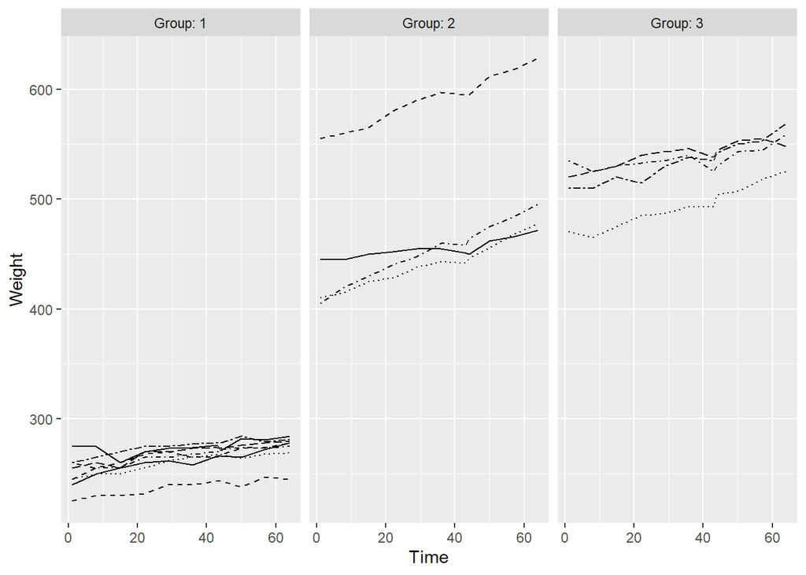

```r
#Access the package ggplot2
library(ggplot2)

# Draw the plot
ggplot(RATSL, aes(x = Time, y = Weight, linetype = ID)) +
  geom_line() +
  scale_linetype_manual(values = rep(1:10, times=4)) +
  facet_grid(. ~ Group, labeller = label_both) +
  theme(legend.position = "none") +
  scale_y_continuous(limits = c(min(RATSL$Weight), max(RATSL$Weight)))
```

Rats in group 1 seems to have the weights <300, group 2 >400 as well as group 3 > 450 have some overlapping values, but in the group 2 the rats have get more weight faster than in the two other groups. Next we use the tracking (the tracking is more obvious in a plot of the standardized values of each observation).

```r
# Standardise the variable ratsl
RATSL_ <- RATSL %>%
  group_by(Group, Time) %>%
  mutate(stdrats = (Weight - mean(Weight))/sd(Weight) ) %>%
  ungroup()

# Glimpse the data
glimpse(RATSL_)
```

```
## Rows: 176
## Columns: 6
## $ ID      <fct> 1, 2, 3, 4, 5, 6, 7, 8, 9, 10, 11, 12, 13, 14, 15, 16, 1, 2...
## $ Group   <fct> 1, 1, 1, 1, 1, 1, 1, 1, 2, 2, 2, 2, 3, 3, 3, 3, 1, 1, 1, 1,...
## $ WD      <chr> "WD1", "WD1", "WD1", "WD1", "WD1", "WD1", "WD1", "WD1", "WD...
## $ Weight  <int> 240, 225, 245, 260, 255, 260, 275, 245, 410, 405, 445, 555,...
## $ Time    <int> 1, 1, 1, 1, 1, 1, 1, 1, 1, 1, 1, 1, 1, 1, 1, 1, 8, 8, 8, 8,...
## $ stdrats <dbl> -0.6980223, -1.6834654, -0.3695412, 0.6159020, 0.2874209, 0...
```

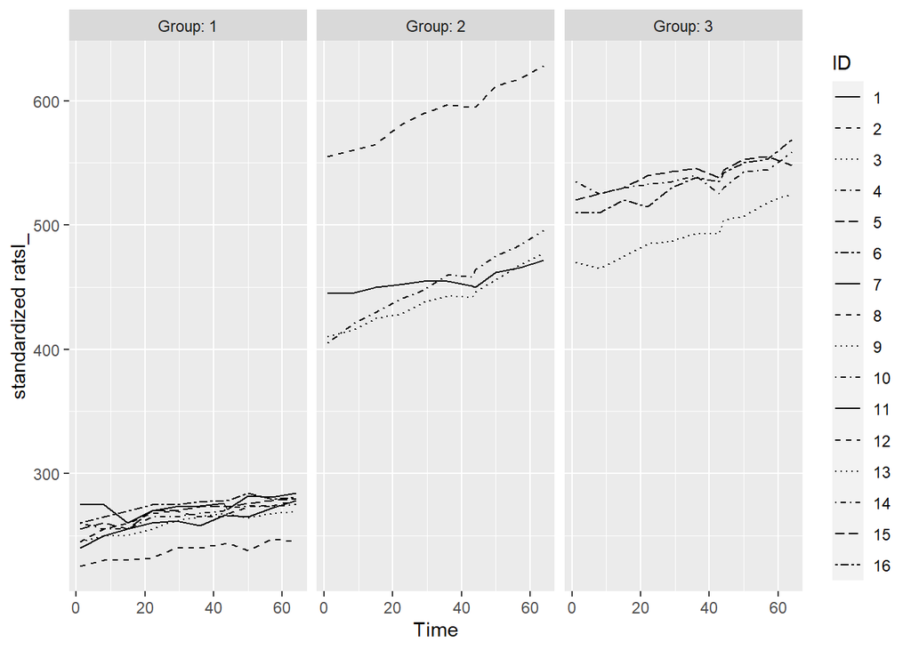

```r
# Plot again with the standardised ratsl_
ggplot(RATSL_, aes(x = Time, y = Weight, linetype = ID)) +
  geom_line() +
  scale_linetype_manual(values = rep(1:10, times=4)) +
  facet_grid(. ~ Group, labeller = label_both) +
  scale_y_continuous(name = "standardized ratsl_")
```

Next we look at the variation of the observations at each time point, therefore we create the mean and standard error of the variable

```r
# Number of weeks, baseline (week 0) included
n <- RATSL_$Time %>% unique() %>% length()

# Summary data with mean and standard error of ratsl_ by Group and Time
RATSS <- RATSL_ %>%
  group_by(Group, Time) %>%
  summarise( mean = mean(Weight), se = sd(Weight)/sqrt(n) ) %>%
  ungroup()
# Glimpse the data
glimpse(RATSS)
```

```
## Rows: 33
## Columns: 4
## $ Group <fct> 1, 1, 1, 1, 1, 1, 1, 1, 1, 1, 1, 2, 2, 2, 2, 2, 2, 2, 2, 2, 2...
## $ Time  <int> 1, 8, 15, 22, 29, 36, 43, 44, 50, 57, 64, 1, 8, 15, 22, 29, 3...
## $ mean  <dbl> 250.625, 255.000, 254.375, 261.875, 264.625, 265.000, 267.375...
## $ se    <dbl> 4.589478, 3.947710, 3.460116, 4.100800, 3.333956, 3.552939, 3...
```

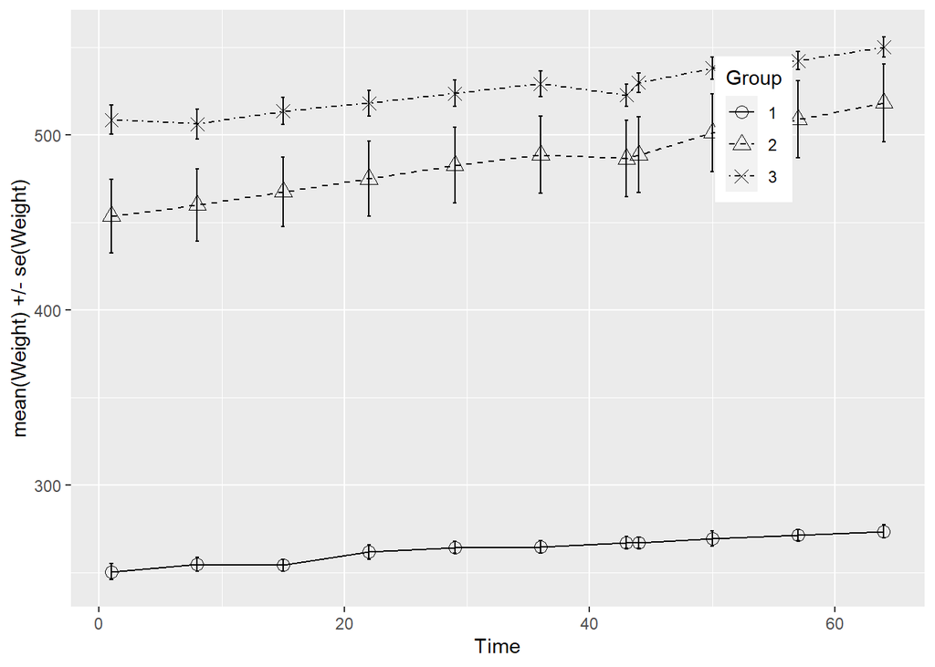

```r
# Plot the mean profiles
ggplot(RATSS, aes(x = Time, y = mean, linetype = Group, shape = Group)) +
  geom_line() +
  scale_linetype_manual(values = c(1,2,4)) +
  geom_point(size=3) +
  scale_shape_manual(values = c(1,2,4)) +
  geom_errorbar(aes(ymin = mean - se, ymax = mean + se, linetype="1"), width=0.3) +
  theme(legend.position = c(0.8,0.8)) +
  scale_y_continuous(name = "mean(Weight) +/- se(Weight)")
```

Group 2 seems to have more variance than the other groups.  
Next we use summary measure approach, the mean of time is out summary measure. Therefore we fist calculate this measure and then look at boxplots of the measure for each Group. Boxplot can reveal outlier(s)

```r
# Create a summary data by treatment and subject with mean as the summary variable (ignoring baseline ).
RATSL8S <- RATSL %>%
  filter(Time > 0) %>%
  group_by(Group, ID) %>%
  summarise( mean=mean(Weight) ) %>%
  ungroup()
# Glimpse the data
glimpse(RATSL8S)
```

```
## Rows: 16
## Columns: 3
## $ Group <fct> 1, 1, 1, 1, 1, 1, 1, 1, 2, 2, 2, 2, 3, 3, 3, 3
## $ ID    <fct> 1, 2, 3, 4, 5, 6, 7, 8, 9, 10, 11, 12, 13, 14, 15, 16
## $ mean  <dbl> 261.0909, 237.6364, 260.1818, 266.5455, 269.4545, 274.7273, 2...
```

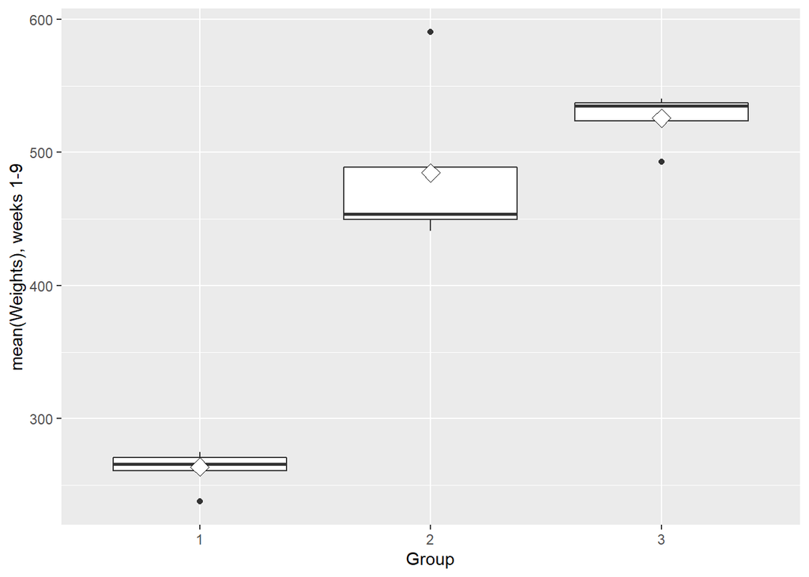

```r
# Draw a boxplot of the mean versus treatment
ggplot(RATSL8S, aes(x = Group, y = mean)) +
  geom_boxplot() +
  stat_summary(fun.y = "mean", geom = "point", shape=23, size=4, fill = "white") +
  scale_y_continuous(name = "mean(Weights), weeks 1-9")
```

```r
#RATS8S1 <- RATSL8S %>% filter( (mean > 240 & Group == 1) | (mean < 480 & Group == 2) | (mean > 500 & Group == 3) )
#glimpse(RATS8S1)
```

The formal test for a defference is performed with a t-test to assess any difference between the groups and also calculate a confidence interval for this differences.

```r
# Create a new data by filtering the outlier and adjust the ggplot code the draw the plot again with the new data
RATSL8S1 <- RATSL8S %>%
  filter(mean < 480)

# Perform a two-sample t-test
t.test(mean~Group, data = RATSL8S1, var.equal = TRUE)
```

```
##
##  Two Sample t-test
##
## data:  mean by Group
## t = -24.838, df = 9, p-value = 1.334e-09
## alternative hypothesis: true difference in means is not equal to 0
## 95 percent confidence interval:
##  -202.6549 -168.8224
## sample estimates:
## mean in group 1 mean in group 2
##        263.7159        449.4545
```

```r
# Add the baseline from the original data as a new variable to the summary data
RATSL8S2 <- RATSL8S %>%
  mutate(baseline = RATS$WD1)

# Fit the linear model with the mean as the response
fit <- lm(mean ~ baseline + Group, data = RATSL8S2)

# Compute the analysis of variance table for the fitted model with anova()
anova(fit)
```

```
## Analysis of Variance Table
##
## Response: mean
##           Df Sum Sq Mean Sq   F value    Pr(>F)
## baseline   1 252125  252125 2237.0655 5.217e-15 ***
## Group      2    726     363    3.2219   0.07586 .
## Residuals 12   1352     113
## ---
## Signif. codes:  0 '***' 0.001 '**' 0.01 '*' 0.05 '.' 0.1 ' ' 1
```

# Linear Mixed Effects

```r
#read the data into memory
BPRS <- read.table("https://raw.githubusercontent.com/KimmoVehkalahti/MABS/master/Examples/data/BPRS.txt", sep = " ", header = T)

# Factor treatment & subject
BPRS$treatment <- factor(BPRS$treatment)
BPRS$subject <- factor(BPRS$subject)


# Glimpse the data
glimpse(BPRS)
```

```
## Rows: 40
## Columns: 11
## $ treatment <fct> 1, 1, 1, 1, 1, 1, 1, 1, 1, 1, 1, 1, 1, 1, 1, 1, 1, 1, 1, ...
## $ subject   <fct> 1, 2, 3, 4, 5, 6, 7, 8, 9, 10, 11, 12, 13, 14, 15, 16, 17...
## $ week0     <int> 42, 58, 54, 55, 72, 48, 71, 30, 41, 57, 30, 55, 36, 38, 6...
## $ week1     <int> 36, 68, 55, 77, 75, 43, 61, 36, 43, 51, 34, 52, 32, 35, 6...
## $ week2     <int> 36, 61, 41, 49, 72, 41, 47, 38, 39, 51, 34, 49, 36, 36, 6...
## $ week3     <int> 43, 55, 38, 54, 65, 38, 30, 38, 35, 55, 41, 54, 31, 34, 4...
## $ week4     <int> 41, 43, 43, 56, 50, 36, 27, 31, 28, 53, 36, 48, 25, 25, 3...
## $ week5     <int> 40, 34, 28, 50, 39, 29, 40, 26, 22, 43, 36, 43, 25, 27, 3...
## $ week6     <int> 38, 28, 29, 47, 32, 33, 30, 26, 20, 43, 38, 37, 21, 25, 2...
## $ week7     <int> 47, 28, 25, 42, 38, 27, 31, 25, 23, 39, 36, 36, 19, 26, 3...
## $ week8     <int> 51, 28, 24, 46, 32, 25, 31, 24, 21, 32, 36, 31, 22, 26, 3...
```

```r
# Convert data to long form
BPRSL <- BPRS %>%
  gather(key = weeks, value = bprs, -treatment, -subject) %>%
  mutate(week = as.integer(substr(weeks,5,6)))

# Glimpse the data
glimpse(BPRSL)
```

```
## Rows: 360
## Columns: 5
## $ treatment <fct> 1, 1, 1, 1, 1, 1, 1, 1, 1, 1, 1, 1, 1, 1, 1, 1, 1, 1, 1, ...
## $ subject   <fct> 1, 2, 3, 4, 5, 6, 7, 8, 9, 10, 11, 12, 13, 14, 15, 16, 17...
## $ weeks     <chr> "week0", "week0", "week0", "week0", "week0", "week0", "we...
## $ bprs      <int> 42, 58, 54, 55, 72, 48, 71, 30, 41, 57, 30, 55, 36, 38, 6...
## $ week      <int> 0, 0, 0, 0, 0, 0, 0, 0, 0, 0, 0, 0, 0, 0, 0, 0, 0, 0, 0, ...
```

```r
# Check the dimensions of the data
dim(BPRSL)
```

```
## [1] 360   5
```

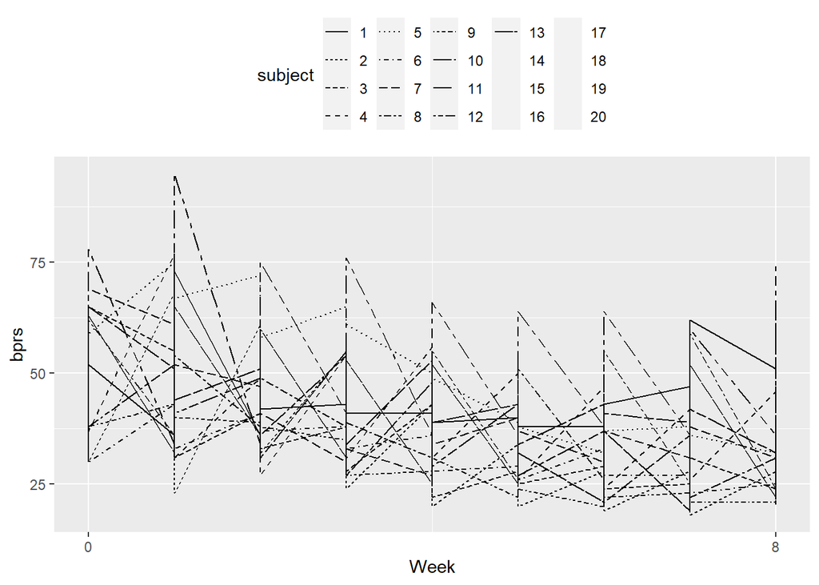

```r
# Plot the RATSL data
ggplot(BPRSL, aes(x = week, y = bprs, group = subject)) +
  geom_line(aes(linetype = subject)) +
  scale_x_continuous(name = "Week", breaks = seq(0, 60, 8)) +
  scale_y_continuous(name = "bprs") +
  theme(legend.position = "top")
```

We ignore the repeatead measures structure of data, and we fit a multiple linear regression model with bprs as response and week and subject as explanatory variables

```r
# create a regression model RATS_reg
BPRS_reg <- lm(bprs ~ week + subject, data = BPRSL)

# print out a summary of the model
summary(BPRS_reg)
```

```
##
## Call:
## lm(formula = bprs ~ week + subject, data = BPRSL)
##
## Residuals:
##     Min      1Q  Median      3Q     Max
## -33.193  -6.563  -0.878   4.839  34.078
##
## Coefficients:
##             Estimate Std. Error t value Pr(>|t|)
## (Intercept)  54.3039     2.5513  21.285  < 2e-16 ***
## week         -2.2704     0.2088 -10.875  < 2e-16 ***
## subject2    -11.3889     3.4093  -3.341 0.000929 ***
## subject3    -10.3333     3.4093  -3.031 0.002625 **
## subject4     -4.5556     3.4093  -1.336 0.182370
## subject5      5.6111     3.4093   1.646 0.100722
## subject6    -13.1111     3.4093  -3.846 0.000144 ***
## subject7     -3.8889     3.4093  -1.141 0.254806
## subject8     -2.7778     3.4093  -0.815 0.415773
## subject9    -15.5556     3.4093  -4.563 7.07e-06 ***
## subject10    -1.1667     3.4093  -0.342 0.732408
## subject11     8.8889     3.4093   2.607 0.009530 **
## subject12    -8.0556     3.4093  -2.363 0.018699 *
## subject13    -6.9444     3.4093  -2.037 0.042433 *
## subject14   -13.3889     3.4093  -3.927 0.000104 ***
## subject15    -2.9444     3.4093  -0.864 0.388385
## subject16   -12.7778     3.4093  -3.748 0.000210 ***
## subject17    -7.5000     3.4093  -2.200 0.028489 *
## subject18   -16.1111     3.4093  -4.726 3.37e-06 ***
## subject19   -17.7222     3.4093  -5.198 3.48e-07 ***
## subject20   -17.5556     3.4093  -5.149 4.44e-07 ***
## ---
## Signif. codes:  0 '***' 0.001 '**' 0.01 '*' 0.05 '.' 0.1 ' ' 1
##
## Residual standard error: 10.23 on 339 degrees of freedom
## Multiple R-squared:  0.4706, Adjusted R-squared:  0.4394
## F-statistic: 15.07 on 20 and 339 DF,  p-value: < 2.2e-16
```

```r
#
```

```r
# access library lme4
library(lme4)
```

```r
library(ggplot2)



# Create a random intercept model
BPRS_ref <- lmer(bprs ~ week + subject + (1 | treatment), data = BPRSL, REML = FALSE)
```

```
## boundary (singular) fit: see ?isSingular
```

```r
# Print the summary of the model
summary(BPRS_ref)
```

```
## Linear mixed model fit by maximum likelihood  ['lmerMod']
## Formula: bprs ~ week + subject + (1 | treatment)
##    Data: BPRSL
##
##      AIC      BIC   logLik deviance df.resid
##   2720.1   2809.5  -1337.0   2674.1      337
##
## Scaled residuals:
##     Min      1Q  Median      3Q     Max
## -3.3444 -0.6613 -0.0884  0.4875  3.4335
##
## Random effects:
##  Groups    Name        Variance Std.Dev.
##  treatment (Intercept)  0.00    0.000
##  Residual              98.51    9.925
## Number of obs: 360, groups:  treatment, 2
##
## Fixed effects:
##             Estimate Std. Error t value
## (Intercept)  54.3039     2.4757  21.935
## week         -2.2704     0.2026 -11.207
## subject2    -11.3889     3.3083  -3.442
## subject3    -10.3333     3.3083  -3.123
## subject4     -4.5556     3.3083  -1.377
## subject5      5.6111     3.3083   1.696
## subject6    -13.1111     3.3083  -3.963
## subject7     -3.8889     3.3083  -1.175
## subject8     -2.7778     3.3083  -0.840
## subject9    -15.5556     3.3083  -4.702
## subject10    -1.1667     3.3083  -0.353
## subject11     8.8889     3.3083   2.687
## subject12    -8.0556     3.3083  -2.435
## subject13    -6.9444     3.3083  -2.099
## subject14   -13.3889     3.3083  -4.047
## subject15    -2.9444     3.3083  -0.890
## subject16   -12.7778     3.3083  -3.862
## subject17    -7.5000     3.3083  -2.267
## subject18   -16.1111     3.3083  -4.870
## subject19   -17.7222     3.3083  -5.357
## subject20   -17.5556     3.3083  -5.306
```

```
##
## Correlation matrix not shown by default, as p = 21 > 12.
## Use print(x, correlation=TRUE)  or
##     vcov(x)        if you need it
```

```
## optimizer (nloptwrap) convergence code: 0 (OK)
## boundary (singular) fit: see ?isSingular
```

```r
# create a random intercept and random slope model
BPRS_ref1 <- lmer(bprs ~ week + subject + (week | treatment), data = BPRSL, REML = FALSE)
```

```
## boundary (singular) fit: see ?isSingular
```

```r
# print a summary of the model
summary(BPRS_ref1)
```

```
## Linear mixed model fit by maximum likelihood  ['lmerMod']
## Formula: bprs ~ week + subject + (week | treatment)
##    Data: BPRSL
##
##      AIC      BIC   logLik deviance df.resid
##   2723.7   2820.9  -1336.9   2673.7      335
##
## Scaled residuals:
##     Min      1Q  Median      3Q     Max
## -3.3993 -0.6626 -0.0768  0.4824  3.4736
##
## Random effects:
##  Groups    Name        Variance Std.Dev. Corr
##  treatment (Intercept)  0.5479  0.7402
##            week         0.0535  0.2313   -1.00
##  Residual              98.1144  9.9053
## Number of obs: 360, groups:  treatment, 2
##
## Fixed effects:
##             Estimate Std. Error t value
## (Intercept)  54.3039     2.5256  21.501
## week         -2.2704     0.2601  -8.730
## subject2    -11.3889     3.3018  -3.449
## subject3    -10.3333     3.3018  -3.130
## subject4     -4.5556     3.3018  -1.380
## subject5      5.6111     3.3018   1.699
## subject6    -13.1111     3.3018  -3.971
## subject7     -3.8889     3.3018  -1.178
## subject8     -2.7778     3.3018  -0.841
## subject9    -15.5556     3.3018  -4.711
## subject10    -1.1667     3.3018  -0.353
## subject11     8.8889     3.3018   2.692
## subject12    -8.0556     3.3018  -2.440
## subject13    -6.9444     3.3018  -2.103
## subject14   -13.3889     3.3018  -4.055
## subject15    -2.9444     3.3018  -0.892
## subject16   -12.7778     3.3018  -3.870
## subject17    -7.5000     3.3018  -2.272
## subject18   -16.1111     3.3018  -4.880
## subject19   -17.7222     3.3018  -5.368
## subject20   -17.5556     3.3018  -5.317
```

```
##
## Correlation matrix not shown by default, as p = 21 > 12.
## Use print(x, correlation=TRUE)  or
##     vcov(x)        if you need it
```

```
## optimizer (nloptwrap) convergence code: 0 (OK)
## boundary (singular) fit: see ?isSingular
```

```r
# perform an ANOVA test on the two models
anova(BPRS_ref1, BPRS_ref)
```

```
## Data: BPRSL
## Models:
## BPRS_ref: bprs ~ week + subject + (1 | treatment)
## BPRS_ref1: bprs ~ week + subject + (week | treatment)
##           npar    AIC    BIC  logLik deviance Chisq Df Pr(>Chisq)
## BPRS_ref    23 2720.1 2809.5 -1337.0   2674.1
## BPRS_ref1   25 2723.7 2820.9 -1336.9   2673.7  0.35  2     0.8395
```

```r
# create a random intercept and random slope model
BPRS_ref2 <- lmer(bprs ~ week * subject + (week | treatment), data = BPRSL, REML = FALSE)
```

```
## boundary (singular) fit: see ?isSingular
```

```r
# print a summary of the model
summary(BPRS_ref2)
```

```
## Linear mixed model fit by maximum likelihood  ['lmerMod']
## Formula: bprs ~ week * subject + (week | treatment)
##    Data: BPRSL
##
##      AIC      BIC   logLik deviance df.resid
##   2715.5   2886.5  -1313.8   2627.5      316
##
## Scaled residuals:
##     Min      1Q  Median      3Q     Max
## -3.0803 -0.6434 -0.0458  0.5933  4.1270
##
## Random effects:
##  Groups    Name        Variance Std.Dev. Corr
##  treatment (Intercept)  0.64026 0.8002
##            week         0.06252 0.2500   -1.00
##  Residual              86.23010 9.2860
## Number of obs: 360, groups:  treatment, 2
##
## Fixed effects:
##                Estimate Std. Error t value
## (Intercept)     44.2889     4.0753  10.868
## week             0.2333     0.8659   0.269
## subject2         3.2778     5.7075   0.574
## subject3         3.8333     5.7075   0.672
## subject4         4.0778     5.7075   0.714
## subject5        27.5778     5.7075   4.832
## subject6        -3.5778     5.7075  -0.627
## subject7        12.2444     5.7075   2.145
## subject8        -0.5778     5.7075  -0.101
## subject9        -2.9222     5.7075  -0.512
## subject10        8.2333     5.7075   1.443
## subject11       13.7556     5.7075   2.410
## subject12        3.7444     5.7075   0.656
## subject13        6.5556     5.7075   1.149
## subject14       -6.4222     5.7075  -1.125
## subject15       12.5222     5.7075   2.194
## subject16       -0.4444     5.7075  -0.078
## subject17       -4.8000     5.7075  -0.841
## subject18      -12.1444     5.7075  -2.128
## subject19       -8.6889     5.7075  -1.522
## subject20       -7.2222     5.7075  -1.265
## week:subject2   -3.6667     1.1988  -3.059
## week:subject3   -3.5417     1.1988  -2.954
## week:subject4   -2.1583     1.1988  -1.800
## week:subject5   -5.4917     1.1988  -4.581
## week:subject6   -2.3833     1.1988  -1.988
## week:subject7   -4.0333     1.1988  -3.364
## week:subject8   -0.5500     1.1988  -0.459
## week:subject9   -3.1583     1.1988  -2.635
## week:subject10  -2.3500     1.1988  -1.960
## week:subject11  -1.2167     1.1988  -1.015
## week:subject12  -2.9500     1.1988  -2.461
## week:subject13  -3.3750     1.1988  -2.815
## week:subject14  -1.7417     1.1988  -1.453
## week:subject15  -3.8667     1.1988  -3.225
## week:subject16  -3.0833     1.1988  -2.572
## week:subject17  -0.6750     1.1988  -0.563
## week:subject18  -0.9917     1.1988  -0.827
## week:subject19  -2.2583     1.1988  -1.884
## week:subject20  -2.5833     1.1988  -2.155
```

```
##
## Correlation matrix not shown by default, as p = 40 > 12.
## Use print(x, correlation=TRUE)  or
##     vcov(x)        if you need it
```

```
## optimizer (nloptwrap) convergence code: 0 (OK)
## boundary (singular) fit: see ?isSingular
```

```r
# perform an ANOVA test on the two models
anova(BPRS_ref2, BPRS_ref1)
```

```
## Data: BPRSL
## Models:
## BPRS_ref1: bprs ~ week + subject + (week | treatment)
## BPRS_ref2: bprs ~ week * subject + (week | treatment)
##           npar    AIC    BIC  logLik deviance  Chisq Df Pr(>Chisq)
## BPRS_ref1   25 2723.7 2820.9 -1336.9   2673.7
## BPRS_ref2   44 2715.5 2886.5 -1313.8   2627.5 46.223 19  0.0004608 ***
## ---
## Signif. codes:  0 '***' 0.001 '**' 0.01 '*' 0.05 '.' 0.1 ' ' 1
```

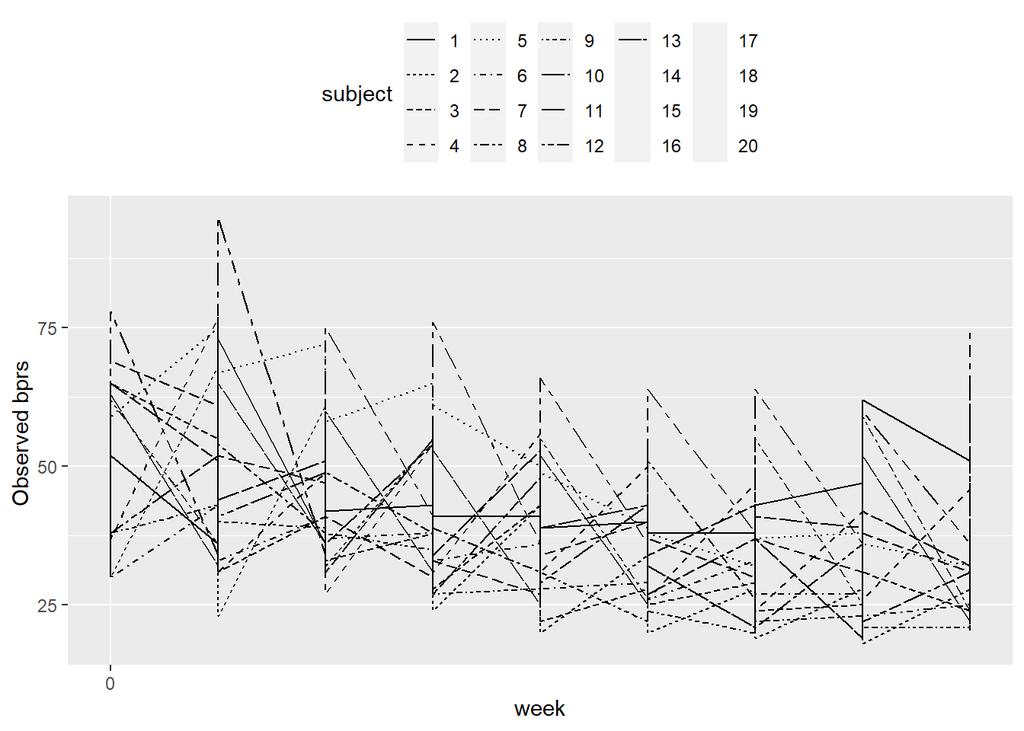

```r
# draw the plot of BPRSL
ggplot(BPRSL, aes(x = week, y = bprs, group = subject)) +
  geom_line(aes(linetype = subject)) +
  scale_x_continuous(name = "week", breaks = seq(0, 60, 20)) +
  scale_y_continuous(name = "Observed bprs ") +
  theme(legend.position = "top")
```

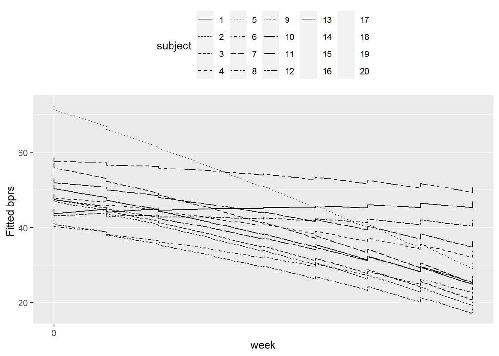

```r
# Create a vector of the fitted values
Fitted <- fitted(BPRS_ref2)

# Create a new column fitted to BPRSL
BPRSL <- BPRSL %>%
  mutate(Fitted)

# draw the plot of BPRSL
ggplot(BPRSL, aes(x = week, y = Fitted, group = subject)) +
  geom_line(aes(linetype = subject)) +
  scale_x_continuous(name = "week", breaks = seq(0, 60, 20)) +
  scale_y_continuous(name = "Fitted bprs ") +
  theme(legend.position = "top")
```